# Assingment 2: diabetes

S. Cernat, J. Regtien, Liebregts, A. , Mans Carlo

2022-11-13

# Introduction

The aim of this project is to predict the incidence of diabetes from patient data, such as blood pressure, insulin levels and blood glucose levels. Diabetes can cause quite serious complications if not discovered in time. On the flip side, it requires costly blood testing to discover the disease. Therefore, if data that is readily available can be employed to classify who has diabetes, this can be quite beneficial, both for early detection as well as from a cost/benefit perspective, as testing can be done in a more directed fashion.

## About the dataset

The source of this data set is the National Institute of Diabetes and Digestive and Kidney Diseases and it only includes data from females of Pima Indian heritage that are at least 21 years of age. About 49% of the observations have missing values, introducing unique challenges to working with this dataset. [Link](https://www.kaggle.com/datasets/akshaydattatraykhare/diabetes-dataset?datasetId=2527538&sortBy=voteCount) to Kaggle dataset.

- Pregnancies: Number of times patient has been pregnant
- Glucose: Plasma glucose concentration at 2 hours in an oral glucose tolerance test
- BloodPressure: Diastolic blood pressure (mm Hg)
- SkinThickness: Triceps skin fold thickness (mm)
- Insulin: 2-Hour serum insulin (mu U/ml)
- BMI: Body mass index (weight in kg/(height in m)^2)
- DiabetesPedigreeFunction: Diabetes pedigree function (diabetes likelihood based on ancestor history)
- Age: Age (years)
- Outcome: Class variable, 0 (no diabetes) or 1 (with diabetes)

# 1. Cleaning

```r
# Load the dataset
set.seed(227)
diabet <- read_csv("./data/diabetes.csv")
```

From just looking at the data it becomes clear that there are a lot of missing values in the form of 0. This seems to be completely at random (MCAR) at a first glance. We will first look for all the columns that have a missing value.

```r
# Look at the column which have a missing value.
diabet %>% arrange_all()
```

```
## # A tibble: 768 × 9
##    Pregnancies Glucose BloodPressure SkinT…¹ Insulin   BMI Diabe…²   Age Outcome
##          <dbl>   <dbl>         <dbl>   <dbl>   <dbl> <dbl>   <dbl> <dbl>   <dbl>
##  1           0      57            60       0       0  21.7   0.735    67       0
##  2           0      67            76       0       0  45.3   0.194    46       0
##  3           0      73             0       0       0  21.1   0.342    25       0
##  4           0      74            52      10      36  27.8   0.269    22       0
##  5           0      78            88      29      40  36.9   0.434    21       0
##  6           0      84            64      22      66  35.8   0.545    21       0
##  7           0      84            82      31     125  38.2   0.233    23       0
##  8           0      86            68      32       0  35.8   0.238    25       0
##  9           0      91            68      32     210  39.9   0.381    25       0
## 10           0      91            80       0       0  32.4   0.601    27       0
## # … with 758 more rows, and abbreviated variable names ¹SkinThickness,
## #   ²DiabetesPedigreeFunction
```

Unfortunately SkinThickness, Insulin , Bloodpressure show missing values (0). Probably, data for Pregancies could be imputated using the age/pregancies distribution. However, we are willing to assume that pregancies = o means that there were in fact 0 pregancies.

```r
# These are the rows which have at least one missing value.
diabet %>% filter(BloodPressure == 0 | SkinThickness == 0 | Insulin == 0)
```

```
## # A tibble: 374 × 9
##    Pregnancies Glucose BloodPressure SkinT…¹ Insulin   BMI Diabe…²   Age Outcome
##          <dbl>   <dbl>         <dbl>   <dbl>   <dbl> <dbl>   <dbl> <dbl>   <dbl>
##  1           6     148            72      35       0  33.6   0.627    50       1
##  2           1      85            66      29       0  26.6   0.351    31       0
##  3           8     183            64       0       0  23.3   0.672    32       1
##  4           5     116            74       0       0  25.6   0.201    30       0
##  5          10     115             0       0       0  35.3   0.134    29       0
##  6           8     125            96       0       0   0     0.232    54       1
##  7           4     110            92       0       0  37.6   0.191    30       0
##  8          10     168            74       0       0  38     0.537    34       1
##  9          10     139            80       0       0  27.1   1.44     57       0
## 10           7     100             0       0       0  30     0.484    32       1
## # … with 364 more rows, and abbreviated variable names ¹SkinThickness,
## #   ²DiabetesPedigreeFunction
```

```r
diabet %>%
  filter(BloodPressure == 0 | SkinThickness == 0 | Insulin == 0) %>%
  group_by(Outcome) %>%
  summarise(count = n())
```

```
## # A tibble: 2 × 2
##   Outcome count
##     <dbl> <int>
## 1       0   236
## 2       1   138
```

We can see above that there does not seem to be a relationship between outcome and the missing values. We will see later that the ratio of Healthy/Disease (0/1) is aprox. 2:1 ratio, just as above.

We will clean the data by: 1. making a column if there is at least one missing value per row 2. transform 1/0 to disease/healthy for convenience 3. make the dependent variable a factor

```r
# Make a new column letting us know if it has a missing value or no
diabet2 <- diabet %>%
  mutate(Missing = ifelse(BloodPressure != 0 & SkinThickness != 0 & Insulin != 0, "No", "Yes")) %>%
  mutate(Outcome = replace(Outcome, Outcome == 1, "Diseased")) %>%
  mutate(Outcome = replace(Outcome, Outcome == 0, "Healthy")) %>%
  mutate(Outcome = as.factor(Outcome))
```

```r
# Remove the 0s
clean_diabet <- diabet2 %>%
  filter(Missing == "No")
```

We will look at the proportions of the outcome in our new cleaned data.

```r
# The proportion of diseased vs healthy
clean_diabet %>%
  group_by(Outcome) %>%
  summarise(count = n()) %>%
  mutate(prop = count/sum(count) )
```

```
## # A tibble: 2 × 3
##   Outcome  count  prop
##   <fct>    <int> <dbl>
## 1 Diseased   130 0.330
## 2 Healthy    264 0.670
```

As stated earlier, the data is skewed , with twice as many healthy vs diseased people. This means the data is unbalanced. For similar problems usually over/under-sampling would be a solution but we think our proportion would is still feasible for modeling.

# 2. EDA

```r
# We can create the below table to get a more quantitative glimpse of the data. We wish to spot meaningful features.

clean_diabet %>%
  group_by(Outcome) %>%
  summarise(Mean_age = mean(Age), Mean_glucose = mean(Glucose), mean_BMI = mean(BMI),
            mean_ST = mean(SkinThickness), mean_BP = mean(BloodPressure), mean_DF = mean(DiabetesPedigreeFunction))
```

```
## # A tibble: 2 × 7
##   Outcome  Mean_age Mean_glucose mean_BMI mean_ST mean_BP mean_DF
##   <fct>       <dbl>        <dbl>    <dbl>   <dbl>   <dbl>   <dbl>
## 1 Diseased     35.9         145.     35.8    33.0    74.1   0.626
## 2 Healthy      28.3         111.     31.6    27.2    69.0   0.476
```

Based on the summary it seems like Diseased people are more likely to have higher values for all features but this is clearly not enough to draw any conclusion.

```r
# Function to plot different variables
plot_density <- function(col, ds = clean_diabet) {
  ds %>% ggplot(aes(x = !!sym(col))) +
    theme_minimal() +
    geom_density(aes(fill = Outcome), alpha = 0.7) +
    scale_fill_brewer(palette = "Set1")
}
```

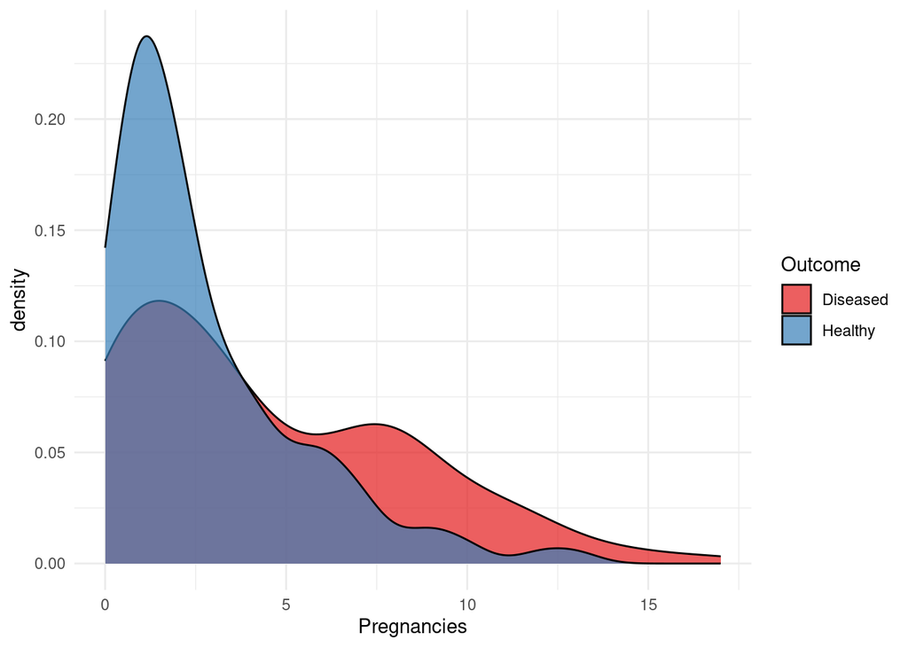

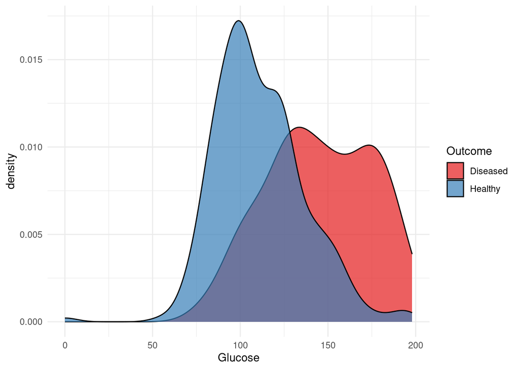

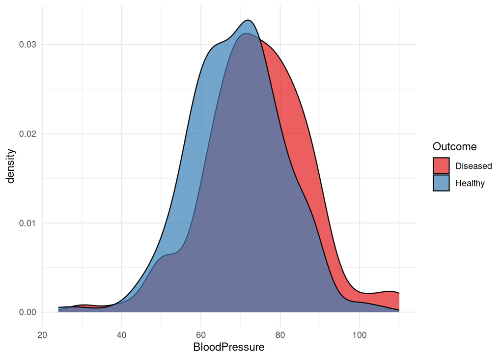

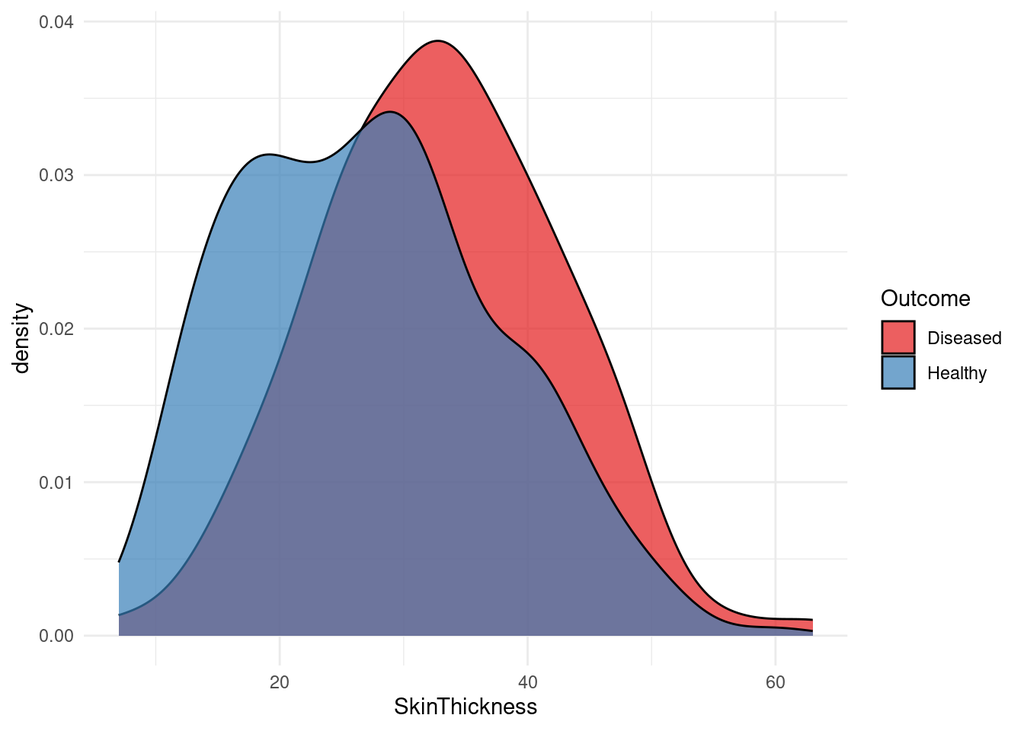

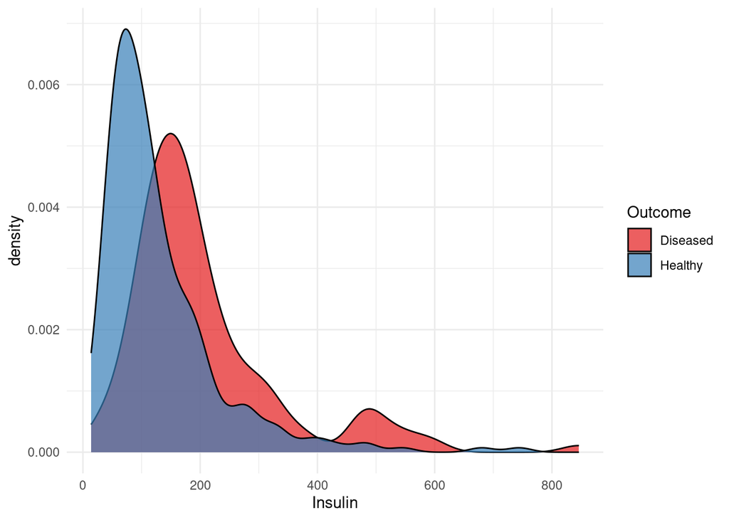

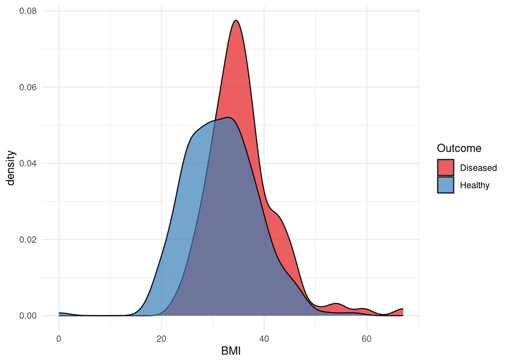

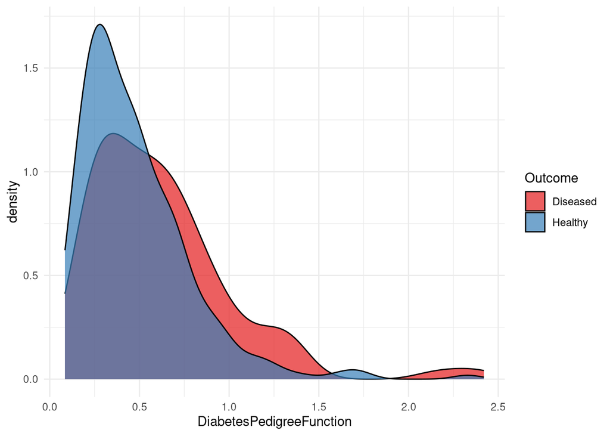

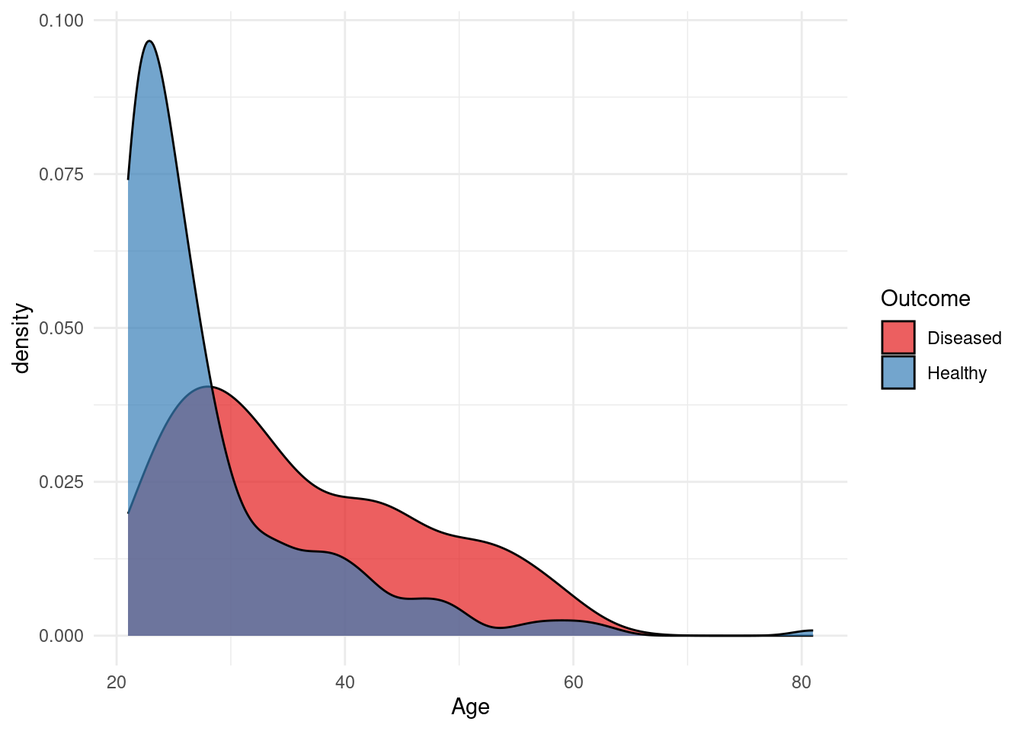

```r
# The distribution of the features relative to the Outcome.

lapply(colnames(clean_diabet)[c(-11, -10, -9)], plot_density)
```

Based on the above plots, it can be assumed that `glucose` levels, `age`, `SkinThickness` and `BMI` would be strong predictors for the disease. On the flip side, `Blood Pressure` likely wouldn’t be a good predictor as the distribution of the Healthy is almost similar to the Diseased . However, because it is unlikely that the variables will always show a very simple relationship with our target variable and because our table is very simplistic and no statistical assumption were actually tested, would still plot some of these *poor* predictors to see if we can *spot meaningful features*.

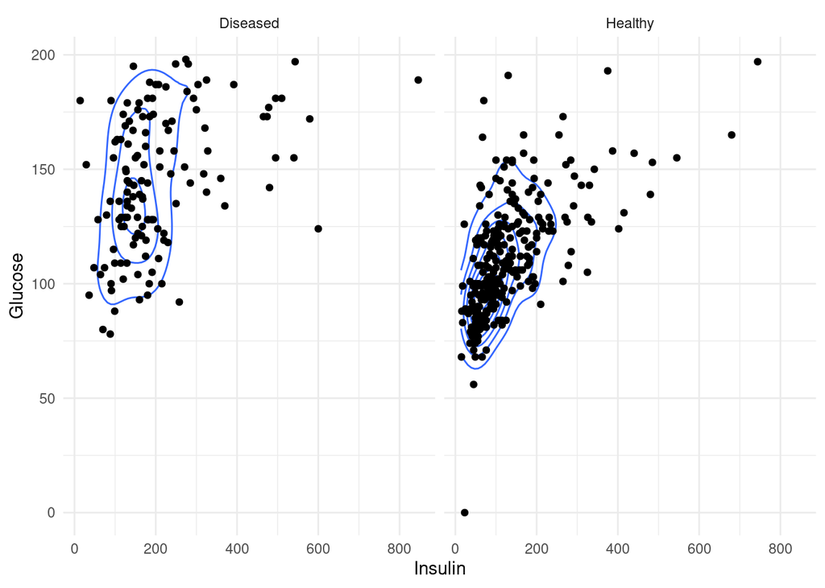

```r
ggplot(data = clean_diabet) +
  geom_density2d(aes(x = Insulin, y = Glucose)) +
  geom_point(aes(x = Insulin, y = Glucose)) +
  facet_wrap(~Outcome) + theme_minimal()
```

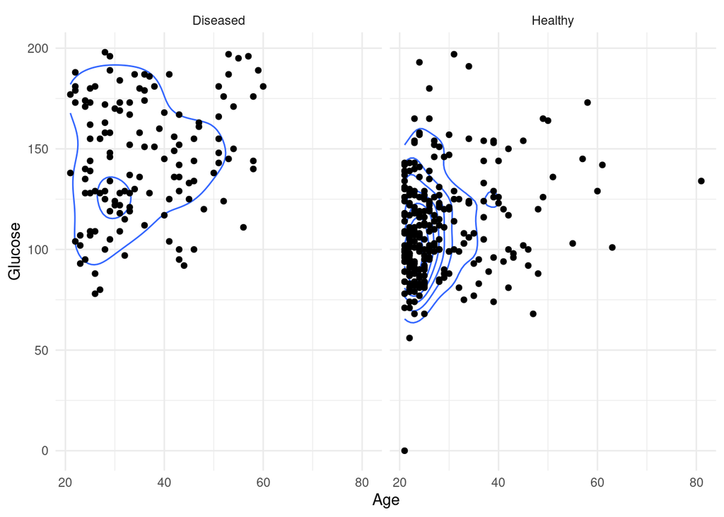

```r
ggplot(data = clean_diabet) +
  geom_density2d(aes(x = Age, y = Glucose)) +
  geom_point(aes(x = Age, y = Glucose)) +
  facet_wrap(~Outcome) + theme_minimal()
```

The above plots suggest that a healthy person is more likely to be younger and have lower glucose levels. For healthy people a linear relationship between glucose and insulin can be spotted.

```r
Dataset2 <- clean_diabet %>%
  mutate(Over35 = Age > 35)
```

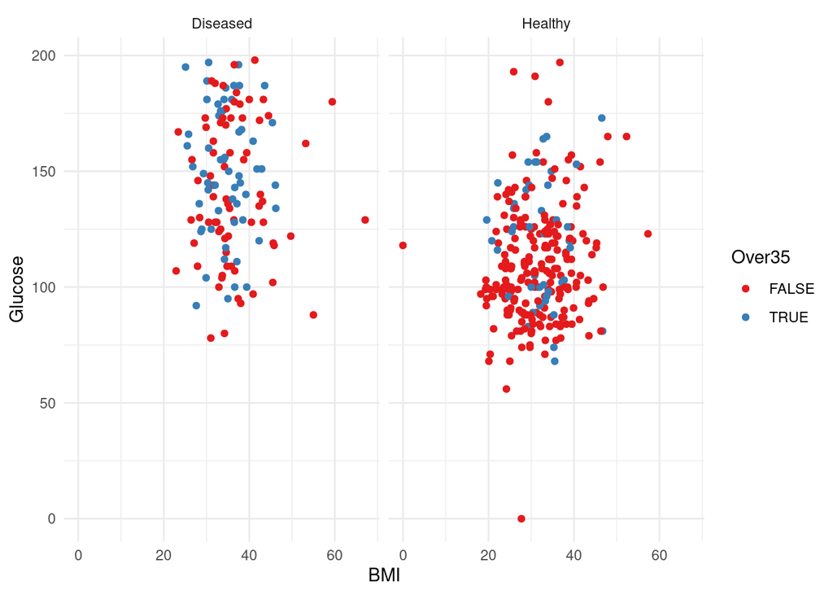

```r
ggplot(data = Dataset2) +
  geom_point(aes(x = BMI, y = Glucose, color = Over35)) +
  facet_grid(cols = vars(Outcome)) +
  scale_color_brewer(palette = "Set1") +
  theme_minimal()
```

LEGEND: TRUE - Age above 35 years; FALSE - Below 35 years

Ultimately, we did a correlation plot so see if features correlate with each other. This is based on Pearson correlation. We tested this because we plan to do a logistic regression, which, because is a linear model can suffer from multicolinearity.

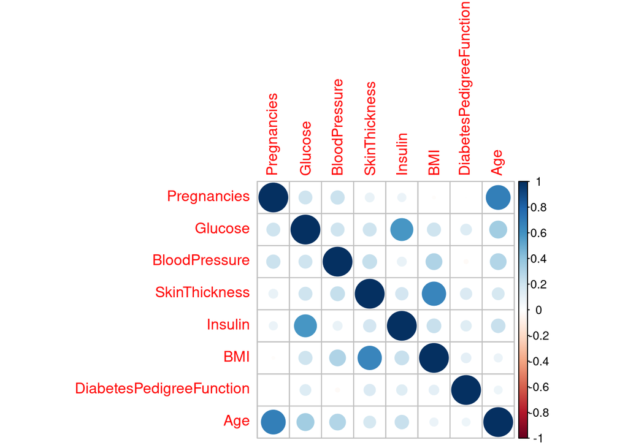

```r
# Correlation between variables

cor <- clean_diabet %>%
  select(-Outcome, -Missing) %>%
  cor()
corrplot(cor)
```

Age is correlated with pregnancies, which is expected. Insulin is correlated with glucose, which we also thought so earlier and it makes sense biologically for healthy people. BMI is also correlated with SkinThickhness.

# Two simple models

In this assignment we want to try the classification performance of trees vs linear regressions. We believe that for the medical field it is important to understand the important features and be easily explained to medical professionals without complicated domain knowledge. Trees and regressions offer the *possibility to explain* their decisions, especially for trees. Logistic regressions can be tuned with the help of the treshold. More on this later.

*We want to consider the diseased patients the positives.* The code below will accomodate this.

```r
# Splitting the data into a test and a training set
clean_diabet$id <- 1:nrow(clean_diabet)
train <- clean_diabet %>% slice_sample(prop = 0.7)
test <- anti_join(clean_diabet, train, by = "id")
```

```r
# The distribution of positives and negatives in the train
test %>%
  group_by(Outcome) %>%
  summarise(count = n())
```

```
## # A tibble: 2 × 2
##   Outcome  count
##   <fct>    <int>
## 1 Diseased    34
## 2 Healthy     85
```

```r
train %>%
  group_by(Outcome) %>%
  summarise(count = n())
```

```
## # A tibble: 2 × 2
##   Outcome  count
##   <fct>    <int>
## 1 Diseased    96
## 2 Healthy    179
```

```r
# Creating a very simple lr model
lazy_lr <- glm(Outcome ~ . -id , family = "binomial", data = train %>% select(-Missing))
summary(lazy_lr)
```

```
##
## Call:
## glm(formula = Outcome ~ . - id, family = "binomial", data = train %>%
##     select(-Missing))
##
## Deviance Residuals:
##     Min       1Q   Median       3Q      Max
## -2.3783  -0.6689   0.3842   0.7075   2.4364
##
## Coefficients:
##                            Estimate Std. Error z value Pr(>|z|)
## (Intercept)               9.2102963  1.3563631   6.790 1.12e-11 ***
## Pregnancies              -0.0502236  0.0621518  -0.808   0.4190
## Glucose                  -0.0376777  0.0069456  -5.425 5.81e-08 ***
## BloodPressure             0.0006905  0.0130050   0.053   0.9577
## SkinThickness            -0.0217000  0.0199054  -1.090   0.2756
## Insulin                   0.0010504  0.0015815   0.664   0.5066
## BMI                      -0.0670004  0.0303407  -2.208   0.0272 *
## DiabetesPedigreeFunction -0.5810387  0.4915845  -1.182   0.2372
## Age                      -0.0217282  0.0204409  -1.063   0.2878
## ---
## Signif. codes:  0 '***' 0.001 '**' 0.01 '*' 0.05 '.' 0.1 ' ' 1
##
## (Dispersion parameter for binomial family taken to be 1)
##
##     Null deviance: 355.79  on 274  degrees of freedom
## Residual deviance: 254.37  on 266  degrees of freedom
## AIC: 272.37
##
## Number of Fisher Scoring iterations: 5
```

```r
# Testing the model on the training
pred <- ifelse(predict(lazy_lr, method = "response", newdata = test) > 0.5, "Healthy", "Diseased")
tab <- table(test$Outcome, pred)

FP <- tab[2, 1]
TP <- tab[1, 1]
TN <- tab[2, 2]
FN <- tab[1, 2]

tibble(
  Acc = (TP + TN) / sum(tab),
  Senz = TP / (TP + FN),
  Spec = TN / (TN + FP),
  FPR = FP / (TN + FP),
  PPV = TP / (TP + FP),
  NPV = TN / (TN + FN)
)
```

```
## # A tibble: 1 × 6
##     Acc  Senz  Spec   FPR   PPV   NPV
##   <dbl> <dbl> <dbl> <dbl> <dbl> <dbl>
## 1 0.773 0.824 0.753 0.247 0.571 0.914
```

```r
#Confusion matrix lazy logistic model
tab
```

```
##           pred
##            Diseased Healthy
##   Diseased       28       6
##   Healthy        21      64
```

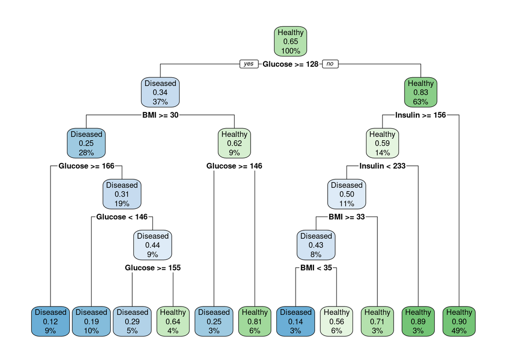

```r
#We will try a simple tree model now
formula <- Outcome ~   Glucose + Insulin +BMI
model_RT <- rpart(formula, data = train)
rpart.plot(model_RT)
```

```r
RT_pred = predict(model_RT, newdata = test, type = 'class')
confusionMatrix(RT_pred, test$Outcome, positive = "Diseased")
```

```
## Confusion Matrix and Statistics
##
##           Reference
## Prediction Diseased Healthy
##   Diseased       25      13
##   Healthy         9      72
##
##                Accuracy : 0.8151
##                  95% CI : (0.7336, 0.8804)
##     No Information Rate : 0.7143
##     P-Value [Acc > NIR] : 0.00788
##
##                   Kappa : 0.5625
##
##  Mcnemar's Test P-Value : 0.52243
##
##             Sensitivity : 0.7353
##             Specificity : 0.8471
##          Pos Pred Value : 0.6579
##          Neg Pred Value : 0.8889
##              Prevalence : 0.2857
##          Detection Rate : 0.2101
##    Detection Prevalence : 0.3193
##       Balanced Accuracy : 0.7912
##
##        'Positive' Class : Diseased
##
```

*Conclusion simple models* Both the simple models performed pretty well on the test set. Both displayed 0.75-0.8 accuracies. The logistic model had a slightly improved sensitivity (for which the positive means diseased). Therefore both models do a bad job at predicting diseased state.

# Improved models

## Trees

```r
#Here we will create a random forest
formula2 <- as.formula(Outcome ~ . -id )
model_RF = randomForest(formula2, data = train %>% select(-Missing))
```

```r
#Predicting and testing the RF model
RF_pred = predict(model_RF, newdata = test, type = 'class')
confusionMatrix(RF_pred, test$Outcome, positive = "Diseased")
```

```
## Confusion Matrix and Statistics
##
##           Reference
## Prediction Diseased Healthy
##   Diseased       25      15
##   Healthy         9      70
##
##                Accuracy : 0.7983
##                  95% CI : (0.7149, 0.8663)
##     No Information Rate : 0.7143
##     P-Value [Acc > NIR] : 0.02412
##
##                   Kappa : 0.5307
##
##  Mcnemar's Test P-Value : 0.30743
##
##             Sensitivity : 0.7353
##             Specificity : 0.8235
##          Pos Pred Value : 0.6250
##          Neg Pred Value : 0.8861
##              Prevalence : 0.2857
##          Detection Rate : 0.2101
##    Detection Prevalence : 0.3361
##       Balanced Accuracy : 0.7794
##
##        'Positive' Class : Diseased
##
```

Next we will try a boosted tree.

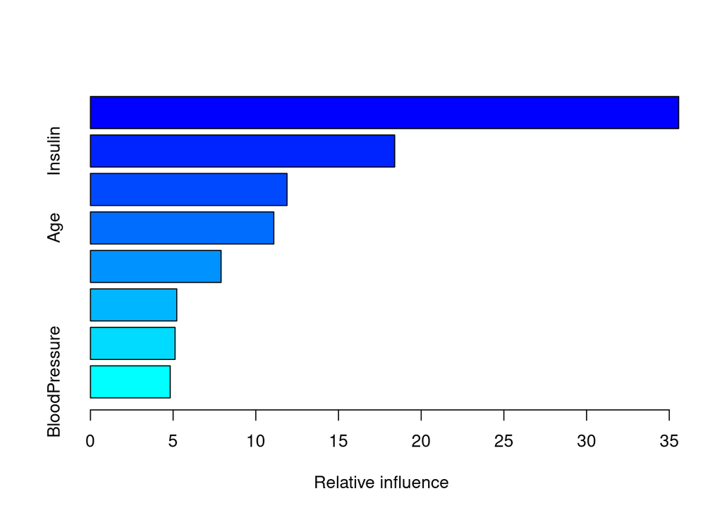

```
##                                               var   rel.inf
## Glucose                                   Glucose 35.570805
## Insulin                                   Insulin 18.396972
## BMI                                           BMI 11.889274
## Age                                           Age 11.087277
## SkinThickness                       SkinThickness  7.898955
## DiabetesPedigreeFunction DiabetesPedigreeFunction  5.220012
## Pregnancies                           Pregnancies  5.115080
## BloodPressure                       BloodPressure  4.821626
```

```r
train <- train[,-10:-11]
cvcontrol <- trainControl(method = "repeatedcv",
                          number = 10,
                          allowParallel = TRUE)
boost <-  train(Outcome ~ .,
                   data = train,
                   method = "gbm",
                   verbose = F,
                   trControl = cvcontrol)
summary(boost)
```

```r
test <- test[,-10:-11]
boostpred <- predict(boost, newdata = test, type = 'raw')
confusionMatrix(boostpred, test$Outcome)
```

```
## Confusion Matrix and Statistics
##
##           Reference
## Prediction Diseased Healthy
##   Diseased       26      13
##   Healthy         8      72
##
##                Accuracy : 0.8235
##                  95% CI : (0.743, 0.8873)
##     No Information Rate : 0.7143
##     P-Value [Acc > NIR] : 0.004178
##
##                   Kappa : 0.5859
##
##  Mcnemar's Test P-Value : 0.382733
##
##             Sensitivity : 0.7647
##             Specificity : 0.8471
##          Pos Pred Value : 0.6667
##          Neg Pred Value : 0.9000
##              Prevalence : 0.2857
##          Detection Rate : 0.2185
##    Detection Prevalence : 0.3277
##       Balanced Accuracy : 0.8059
##
##        'Positive' Class : Diseased
##
```

## Improved logistic regression (with feature selection)

Based on the correlation matrix displayed during the EDA, we have determined that some of the variables showed correlation with each other. We have carefully removed one of the correlated features duos. Here we present the formula which gave us the best performance.

```r
# MODEL 1
formula <- as.formula(Outcome ~ Age + Glucose + BMI )
train_control <- trainControl(method = "cv", number = 4)

model1 <- train(formula,
  data = train,
  trControl = train_control,
  method = "glm",
  family = binomial()
)

summary(model1)
```

```
##
## Call:
## NULL
##
## Deviance Residuals:
##     Min       1Q   Median       3Q      Max
## -2.3715  -0.7180   0.3891   0.7074   2.4985
##
## Coefficients:
##             Estimate Std. Error z value Pr(>|z|)
## (Intercept)  9.05219    1.16668   7.759 8.57e-15 ***
## Age         -0.03488    0.01452  -2.402 0.016307 *
## Glucose     -0.03593    0.00580  -6.195 5.81e-10 ***
## BMI         -0.08363    0.02322  -3.601 0.000317 ***
## ---
## Signif. codes:  0 '***' 0.001 '**' 0.01 '*' 0.05 '.' 0.1 ' ' 1
##
## (Dispersion parameter for binomial family taken to be 1)
##
##     Null deviance: 355.79  on 274  degrees of freedom
## Residual deviance: 258.20  on 271  degrees of freedom
## AIC: 266.2
##
## Number of Fisher Scoring iterations: 5
```

```r
# Predicting LR
pred_lr <- predict(model1, method = "response", newdata = test)
confusionMatrix(pred_lr, test$Outcome, positive = "Diseased")
```

```
## Confusion Matrix and Statistics
##
##           Reference
## Prediction Diseased Healthy
##   Diseased       25      11
##   Healthy         9      74
##
##                Accuracy : 0.8319
##                  95% CI : (0.7524, 0.8942)
##     No Information Rate : 0.7143
##     P-Value [Acc > NIR] : 0.002101
##
##                   Kappa : 0.5954
##
##  Mcnemar's Test P-Value : 0.823063
##
##             Sensitivity : 0.7353
##             Specificity : 0.8706
##          Pos Pred Value : 0.6944
##          Neg Pred Value : 0.8916
##              Prevalence : 0.2857
##          Detection Rate : 0.2101
##    Detection Prevalence : 0.3025
##       Balanced Accuracy : 0.8029
##
##        'Positive' Class : Diseased
##
```

This model presents a 0.83 accuracy. The Sensitivity is 0.73 and Specificity is 0.87. Not bad!

At the beginning of the project we chose to remove the rows which contain missing data. After selecting the relevant features, some of the rows that had missing values on the irrelevant features can be reintroduced both in the training and testing. Turns out that now all the data is reintroduced so know we have twice as many values to train our model.

We now want to remodel the data based on the included rows.

```r
# To reintroduce the data we are going to select take the rows with missing values -> shuffle -> assign 70%/30% to train/test -> assign to previous train/test. Why? we shall compare
diabet_lr <- diabet2 %>% filter(Missing == "Yes")
diabet_lr$id <- 1:nrow(diabet_lr)
train_missing <- diabet_lr %>% slice_sample(prop = 0.7)
test_missing <- anti_join(diabet_lr, train_missing, by = "id")


train_lr <- bind_rows(list(train, train_missing)) %>% select(-Missing)
test_lr <- bind_rows(list(test, test_missing)) %>% select(-Missing)
```

```r
# The distribution of positives and negatives in the new train/test
test_lr %>%
  group_by(Outcome) %>%
  summarise(count = n()) %>%
  mutate(prop = count/sum(count))
```

```
## # A tibble: 2 × 3
##   Outcome  count  prop
##   <fct>    <int> <dbl>
## 1 Diseased    76 0.328
## 2 Healthy    156 0.672
```

```r
train_lr %>%
  group_by(Outcome) %>%
  summarise(count = n()) %>%
  mutate(prop = count/sum(count))
```

```
## # A tibble: 2 × 3
##   Outcome  count  prop
##   <fct>    <int> <dbl>
## 1 Diseased   192 0.358
## 2 Healthy    344 0.642
```

```r
# create new model trained on the new data
model2 <- train(formula,
  data = train_lr,
  trControl = train_control,
  method = "glm",
  family = binomial()
)

summary(model2)
```

```
##
## Call:
## NULL
##
## Deviance Residuals:
##     Min       1Q   Median       3Q      Max
## -2.7852  -0.7971   0.4456   0.7553   2.3875
##
## Coefficients:
##              Estimate Std. Error z value Pr(>|z|)
## (Intercept)  8.265875   0.785223  10.527  < 2e-16 ***
## Age         -0.025251   0.008961  -2.818  0.00483 **
## Glucose     -0.031744   0.003907  -8.126 4.45e-16 ***
## BMI         -0.088172   0.016200  -5.443 5.25e-08 ***
## ---
## Signif. codes:  0 '***' 0.001 '**' 0.01 '*' 0.05 '.' 0.1 ' ' 1
##
## (Dispersion parameter for binomial family taken to be 1)
##
##     Null deviance: 699.35  on 535  degrees of freedom
## Residual deviance: 533.06  on 532  degrees of freedom
## AIC: 541.06
##
## Number of Fisher Scoring iterations: 5
```

```r
model2
```

```
## Generalized Linear Model
##
## 536 samples
##   3 predictor
##   2 classes: 'Diseased', 'Healthy'
##
## No pre-processing
## Resampling: Cross-Validated (4 fold)
## Summary of sample sizes: 402, 402, 402, 402
## Resampling results:
##
##   Accuracy   Kappa
##   0.7649254  0.4630084
```

```r
# Predict the new model MODEL 2
pred_lr_all <- predict(model2, method = "response", newdata = test_lr)
confusionMatrix(pred_lr_all, test_lr$Outcome, positive = "Diseased")
```

```
## Confusion Matrix and Statistics
##
##           Reference
## Prediction Diseased Healthy
##   Diseased       46      25
##   Healthy        30     131
##
##                Accuracy : 0.7629
##                  95% CI : (0.7029, 0.8161)
##     No Information Rate : 0.6724
##     P-Value [Acc > NIR] : 0.001649
##
##                   Kappa : 0.4526
##
##  Mcnemar's Test P-Value : 0.589639
##
##             Sensitivity : 0.6053
##             Specificity : 0.8397
##          Pos Pred Value : 0.6479
##          Neg Pred Value : 0.8137
##              Prevalence : 0.3276
##          Detection Rate : 0.1983
##    Detection Prevalence : 0.3060
##       Balanced Accuracy : 0.7225
##
##        'Positive' Class : Diseased
##
```

```r
#Try the MODEL1 again on the new data
confusionMatrix(predict(model1, method = "response", newdata = test_lr), test_lr$Outcome, positive = "Diseased")
```

```
## Confusion Matrix and Statistics
##
##           Reference
## Prediction Diseased Healthy
##   Diseased       47      20
##   Healthy        29     136
##
##                Accuracy : 0.7888
##                  95% CI : (0.7306, 0.8395)
##     No Information Rate : 0.6724
##     P-Value [Acc > NIR] : 6.159e-05
##
##                   Kappa : 0.5056
##
##  Mcnemar's Test P-Value : 0.2531
##
##             Sensitivity : 0.6184
##             Specificity : 0.8718
##          Pos Pred Value : 0.7015
##          Neg Pred Value : 0.8242
##              Prevalence : 0.3276
##          Detection Rate : 0.2026
##    Detection Prevalence : 0.2888
##       Balanced Accuracy : 0.7451
##
##        'Positive' Class : Diseased
##
```

One of the advantages of logistic regression is that the predictions can be tuned according to a chosen threshold. All the models we showed in this project had poor true positives rate aka they were pretty poor at predicting actual diseased people. We think an threshold can be chosen based on the experience of a clinician. Therefore, we will not choose a threshold as we don’t know what is more dangerous; having diabetes and not knowing or being diagnosed as diabetic without having it ? However, we provide here the means of choosing one.

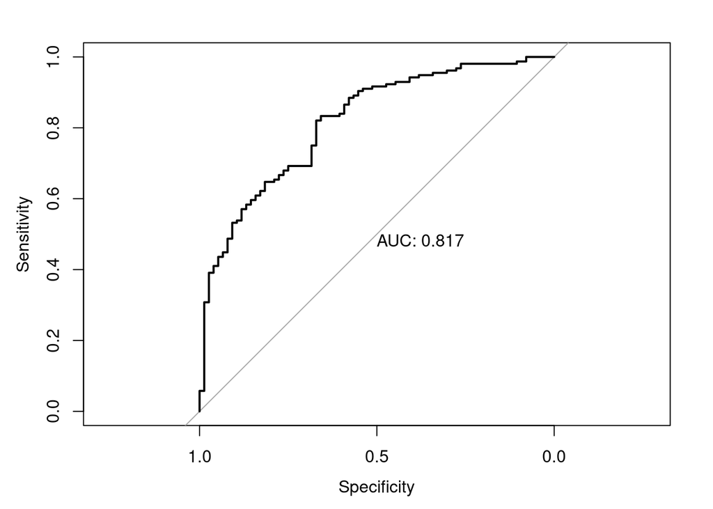

```r
pred_roc <- predict(model2, type = "prob", newdata = test_lr)[, 2]
test_roc <- roc(response = test_lr$Outcome, predictor = pred_roc, plot = TRUE, print.auc = TRUE)
```

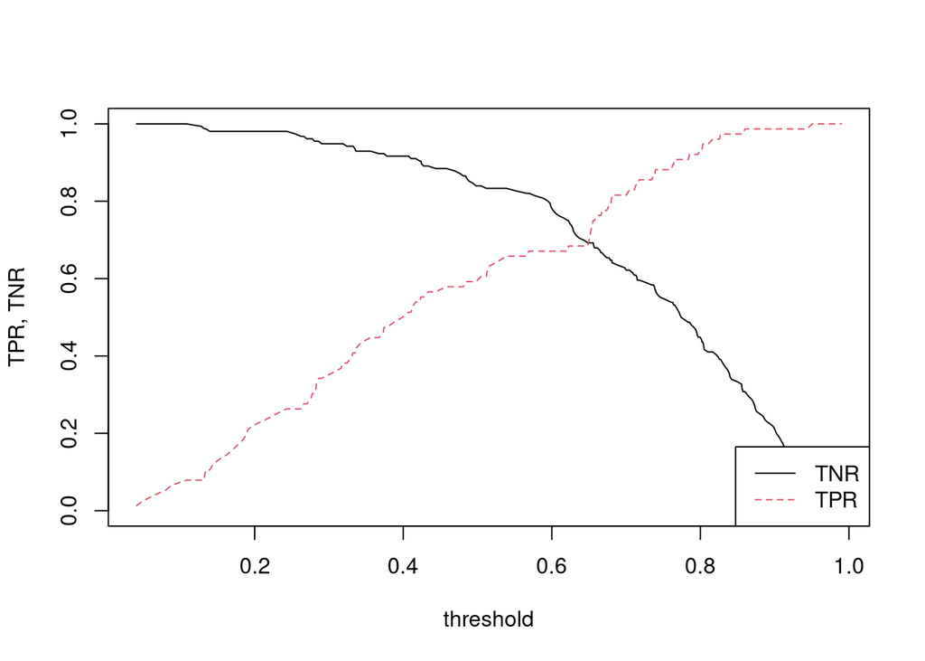

```r
matplot(data.frame(test_roc$sensitivities, test_roc$specificities), x = test_roc$thresholds, type = "l", xlab = "threshold", ylab = "TPR, TNR")
legend("bottomright", legend = c("TNR", "TPR"), lty = 1:2, col = 1:2)
```

#Based on the plot above , if true positive rate needs to be maximized, as we can see that is a problem with our models, we can see that choosing a higher treshold might help .(*The algorithms for our models assumed Diseased to be 0 and Healthy to be 1. We stubbornly wanted Diseased to be the positive one to have a clinical significance*)

# Discussions